# Visualization for Data Exploration & Communication

Uijeong “UJ” Hwang

2026-10-07

# Why visualization?

Data visualization is an essential tool in urban analytics. It provides an intuitive and quick way to understand the characteristics and relationships within your data. A well-designed visualization can sometimes communicate a message more effectively than any other medium, even shaping how people perceive information.

The first thing analysts do when they receive a dataset is try to understand it. One of the most effective ways to do this is through visualization. We have a wide variety of maps and charts to choose from, including scatter plots, histograms, box plots, violin plots, and thematic maps.

```r
library(tidyverse)
library(sf)
library(tmap)
library(leaflet)
library(tidycensus)
library(magrittr)
```

```r
# Let's prepare data
restaurants <- read_rds("https://raw.githubusercontent.com/ujhwang/urban-analytics-2026/main/Lab/module_2/week2/yelp_restaurants.rds")

# Census data
census_var <- c(hhincome = 'B19019_001E',
                race.total = "B02001_001E",
                race.white = "B02001_002E",
                race.black = 'B02001_003E'
                )

census <- get_acs(geography = "tract", state = "GA", county = c("Fulton", "DeKalb"),
                 output = "wide", geometry = TRUE, year = 2024,
                 variables = census_var)

summarise_mean <- c(names(census_var),
                    "rating", "review_count")

census_restaurants <- census %>%
  separate(col = NAME, into=c("tract","county","state"), sep='; ') %>%
  # Spatial join
  st_join(restaurants %>%
            mutate(n = 1,
                   price = nchar(price)) %>%
            st_transform(crs = st_crs(census))) %>%
  # Group_by
  group_by(GEOID, county) %>%
  # Mean for all census variables, sum for n
  summarise(across(
    all_of(summarise_mean), mean),
    n = sum(n),
    price = median(price)) %>%
  # Release grouping
  ungroup() %>%
  # Replace NA in column n&review_count with 0
  mutate(across(c(n, review_count), function(x) case_when(is.na(x) ~ 0, TRUE ~ x)))
```

Let’s first visualize the data on a map. So far, we have mostly used `tmap`, but the `leaflet` package is also an excellent option for interactive mapping with greater customizability.

```r
library(leaflet)
library(htmlwidgets)
library(htmltools)

# CSS for title
tag.map.title <- tags$style(HTML("
  .leaflet-control.map_title {
    position: absolute;
    left: 50px;
    width: 320px;
    text-align: left;
    color: white;
    padding-left: 10px;
    background: rgba(200,200,200,0.2);
    font-weight: bold;
    font-size: 20px;
    font-family: Helvetica;
    border-color: white;
    border-radius: 10px;
  }"))

# Format title
title <- tags$div(
  class="map_title", tag.map.title, HTML("<p>Restaurants in Fulton and DeKalb Counties</p>")
)

# Color palette
fill_pal <- colorQuantile(palette = "YlOrRd", domain=restaurants$review_count)

# Label for mouseover & popup
labels <- paste(
  "<a href=",restaurants$url,">",restaurants$name, "</a><br>",
  "<strong>Review Count: </strong>", restaurants$review_count,"<br>",
  "<strong>Rating: </strong>", restaurants$rating) %>%
  lapply(HTML)

# Creating a Leaflet widget
leaflet() %>%
  # Setting the view on load
  setView(lng = -84.3903996350635, lat = 33.77074368998939, zoom = 10) %>%

  # Dark base map
  addTiles(
    urlTemplate = "https://basemap.queeniemella.cc/tiles/countries/{z}/{x}/{y}.png",
    attribution = "© OpenStreetMap contributors"
  ) %>%

  # Polygon boundary
  addPolygons(data = census %>% st_union(),
              opacity=0.2,
              fillOpacity=0,
              weight=1,
              color="white") %>%

  # Restaurant point
  addCircleMarkers(data = restaurants,
             radius = restaurants$rating*1.5,
             opacity=0.2,
             fillColor=~fill_pal(review_count),
             weight=1,
             color= ~fill_pal(review_count),
             popup= ~labels,
             label= ~labels) %>%

  # Legend
  addLegend("bottomright", pal = fill_pal, values = restaurants$review_count,
            title = "Review Count",opacity = 1) %>%

  # Title
  addControl(title, position="topleft",className="map_title")
```

[interactive chart not shown]

For static maps, the `ggplot2` is another great choice. See [this example](https://timogrossenbacher.ch/bivariate-maps-with-ggplot2-and-sf) for inspiration.

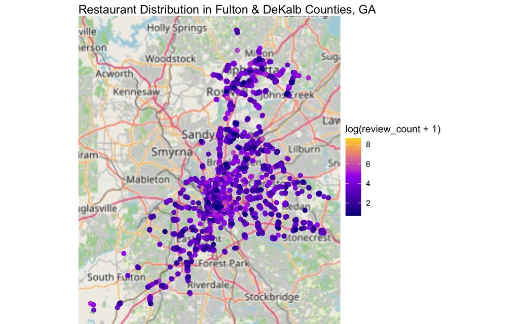

```r
library(ggspatial)
library(prettymapr)

ggplot(data = restaurants) +
  annotation_map_tile(type = "osm") +
  geom_point(mapping = aes(color = log(review_count+1),
                           x = st_coordinates(restaurants)[,1],
                           y = st_coordinates(restaurants)[,2]),
             size=2, alpha=0.9) +
  theme_void() +
  scale_color_gradientn(colours = c("darkblue", "purple", "gold")) +
  labs(title = "Restaurant Distribution in Fulton & DeKalb Counties, GA")
```

# Scatter plot

In `tmap` package, two functions always go hand-in-hand, namely `tm_shape()` and `tm_polygons()` (or `tm_borders`, `tm_lines`, `tm_dots`, etc.). The `tm_shape()` function declares the data object to be displayed. Then, the `tm_polygons()` function defines the geometry shape and other associated characteristics.

A similar structure is used in the `ggplot2` package. Creating a plot needs at least two functions that are connected by `+`: `ggplot()` function and `geom_point()` (or other geometry types, such as `geom_line`, `geom_boxplot`, etc.). In the example below, `ggplot(data = census_restaurants)` indicates that we are drawing ggplot using `census_restaurants` data. Then, `geom_point(aes(x = review_count, y = rating))` shows that we are going to draw a scatter plot using `review_count` and `rating` columns.

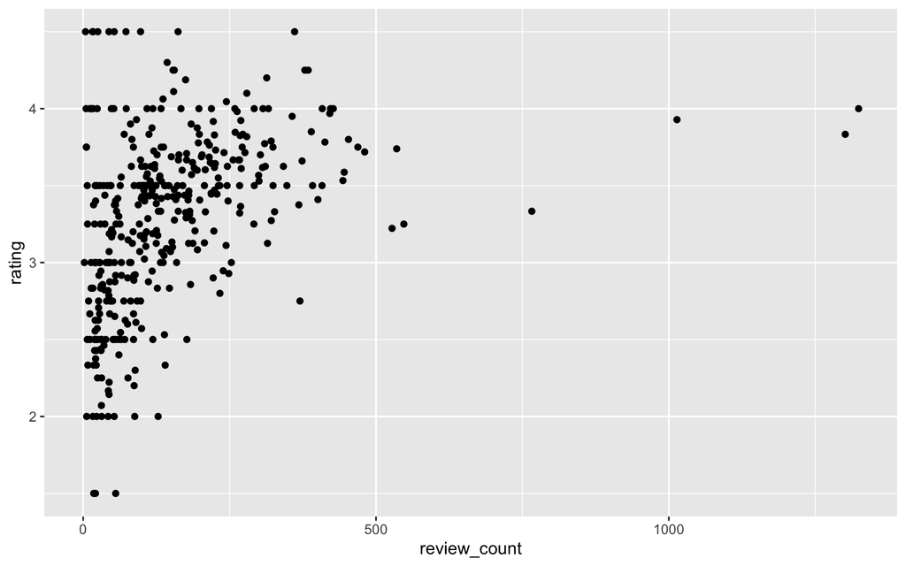

```r
ggplot(data = ????) +
  geom_point(mapping = aes(x = ????, y = ????))
```

## Aesthetic mappings

We can add additional information to this plot using a few different strategies, including colors, sizes, and shapes inside the `aes()` – ‘Aesthetic mappings’ which describe how variables in the data are mapped to visual properties (aesthetics) of geoms. For example, we can add `price` information using color.

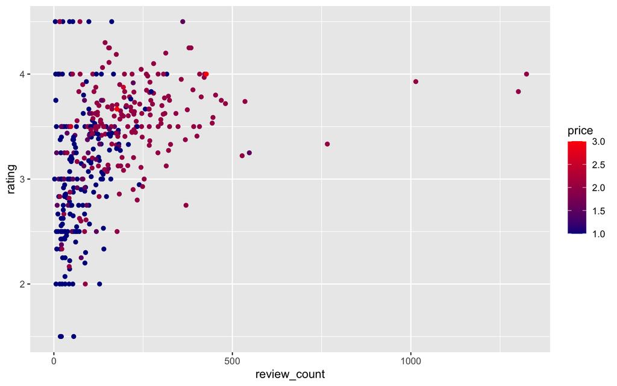

```r
ggplot(data = ????) +
  geom_point(mapping = aes(x=????, y=????,
                           color=????)) + #👈
  scale_color_gradient(low = "darkblue", high = "red")
```

Or size.

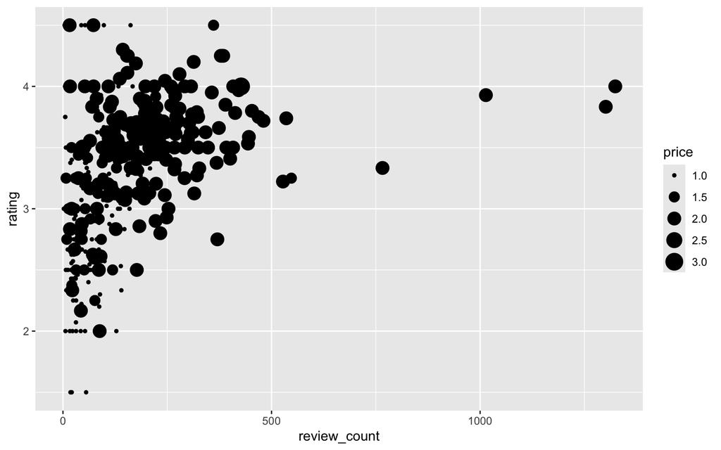

```r
ggplot(data = ????) +
  geom_point(mapping = aes(x=????, y=????,
                          size=????)) #👈
```

Or transparency.

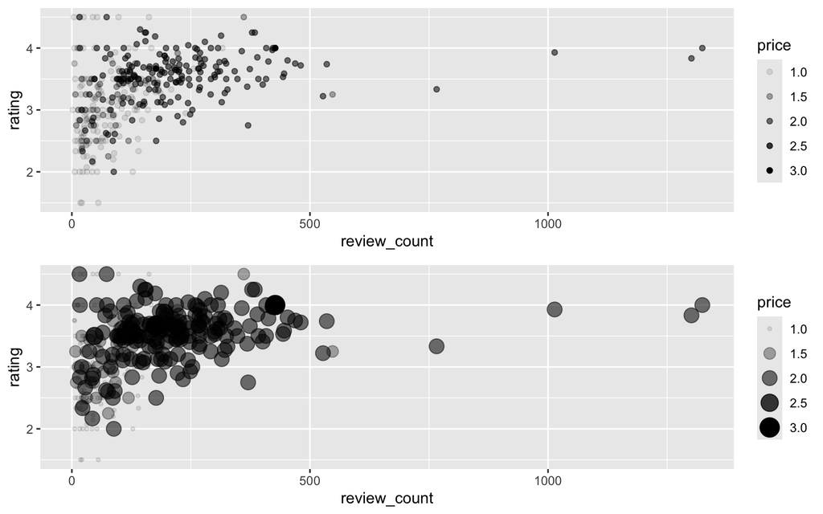

```r
fig1 <- ggplot(data = ????) +
  geom_point(mapping = aes(x=????, y=????,
                           alpha=price)) #👈

fig2 <- ggplot(data = ????) +
  geom_point(mapping = aes(x=????, y=????,
                           alpha=price, #👈
                           size=price)) #👈

gridExtra::grid.arrange(????, ????, ncol= 1)
```

If you put, for example, color and size arguments outside of `aes()`, the visual property from those arguments are not based on your data.

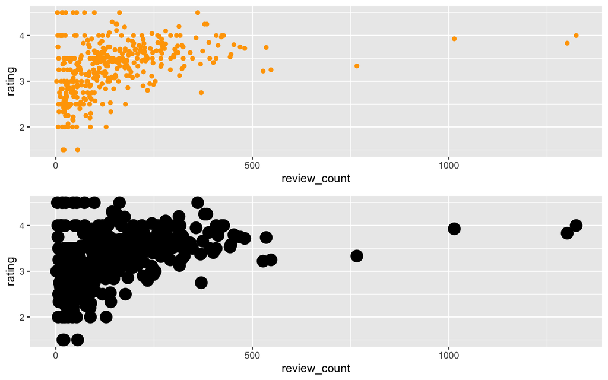

```r
fig2 <- ggplot(data = census_restaurants) +
  geom_point(mapping = aes(x=review_count, y=rating),
             color = "orange") #👈

fig3 <- ggplot(data = census_restaurants) +
  geom_point(mapping = aes(x=review_count, y=rating),
             size = 5) #👈

gridExtra::grid.arrange(fig2, fig3, ncol = 1)
```

## Separating plots by categorical values

Use `facet_wrap` with a categorical variable. Remember that if you use `facet_wrap` with a continuous data, it will generate as many plots as the unique values in the continuous data. Avoid writing such codes!

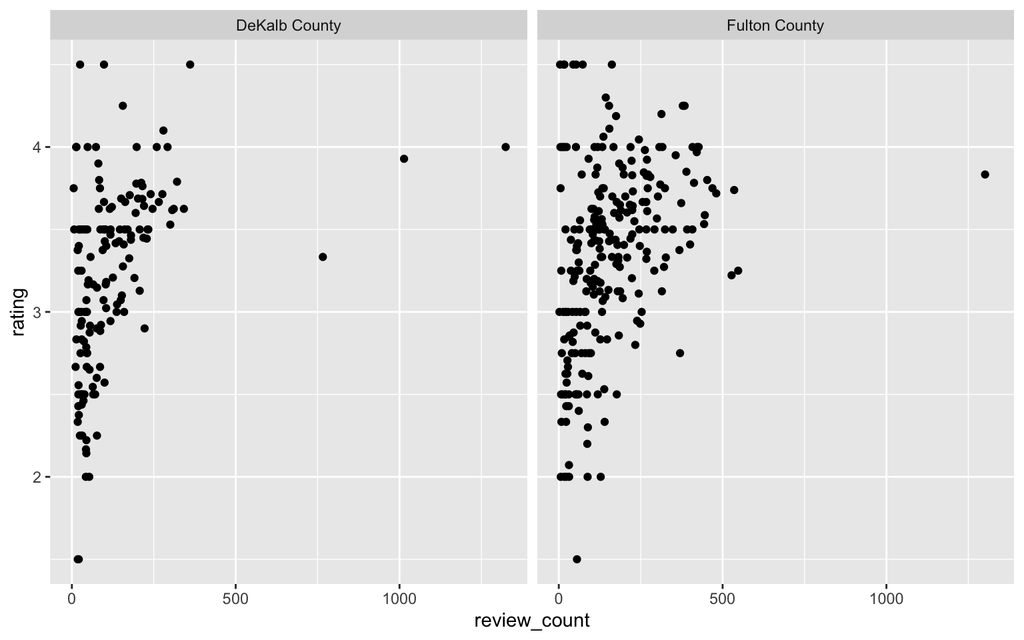

```r
ggplot(data = census_restaurants) +
  geom_point(mapping = aes(x=review_count, y=rating)) +
  facet_wrap(~county) #👈
```

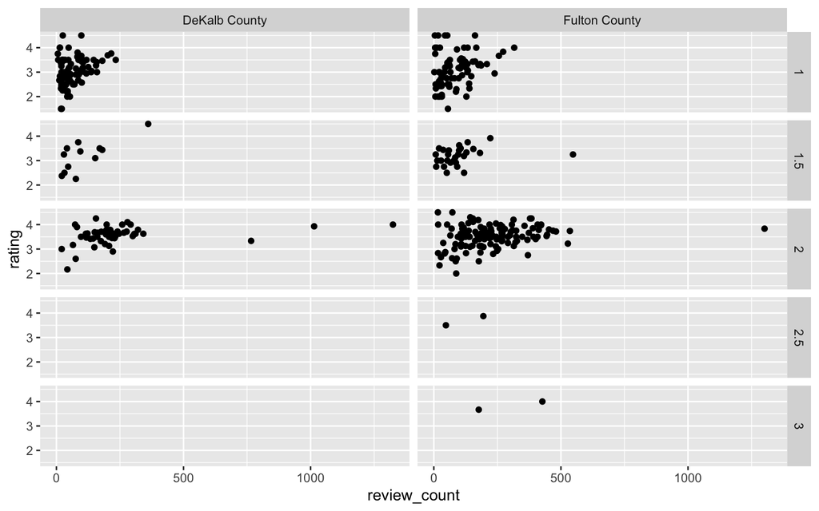

```r
ggplot(data = census_restaurants %>% drop_na(price)) +
  geom_point(mapping = aes(x=review_count, y=rating)) +
  facet_grid(???? ~ ????) #👈
# One will be rows; the other will be columns.
# try swapping the two
```

## Regression line

You can draw a regression line by using `geom_smooth` with the “lm” method.

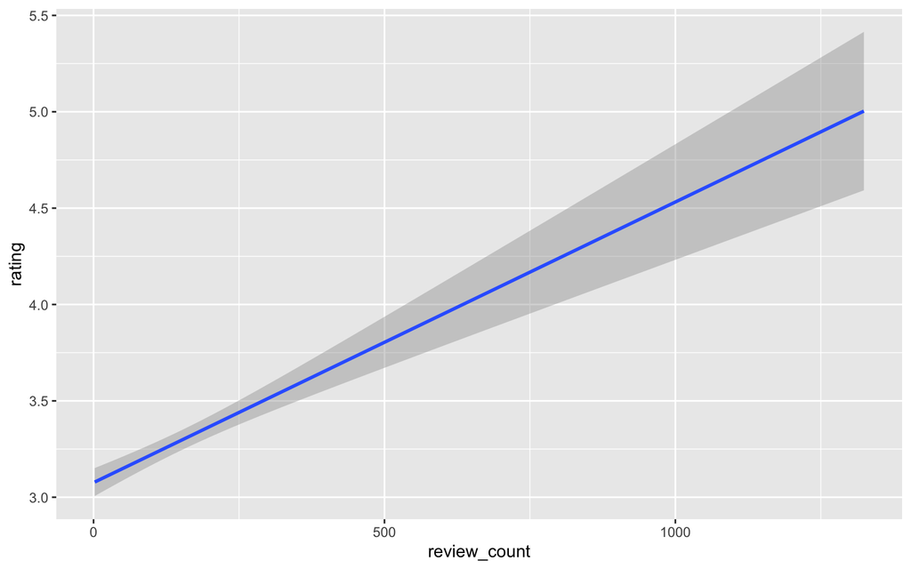

```r
ggplot(data = census_restaurants) +
  geom_????(mapping = aes(x=review_count, y=rating), method = ????)
```

More informative if you show both data points and the regression line.

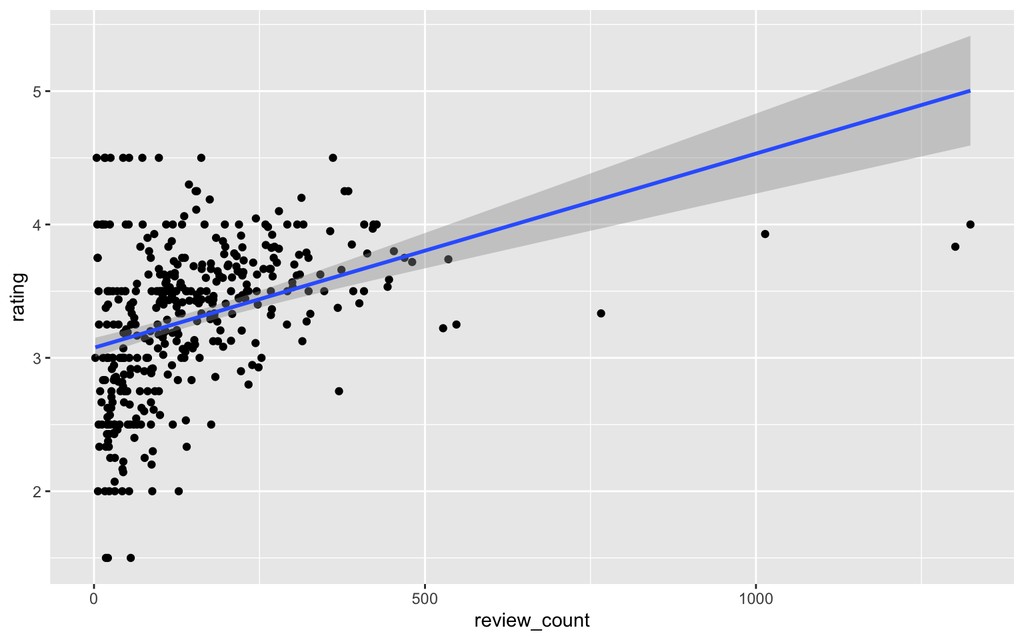

```r
# More than one layers
ggplot(data = census_restaurants) +
  geom_point(mapping = aes(x=review_count, y=rating)) +
  geom_????(mapping = aes(x=review_count, y=rating), method = ????)
```

In the code above, we are repeating `aes(x=review_count, y=rating)` twice. If we know that mapping will be the same in multiple layers, we can define it in `ggplot()`.

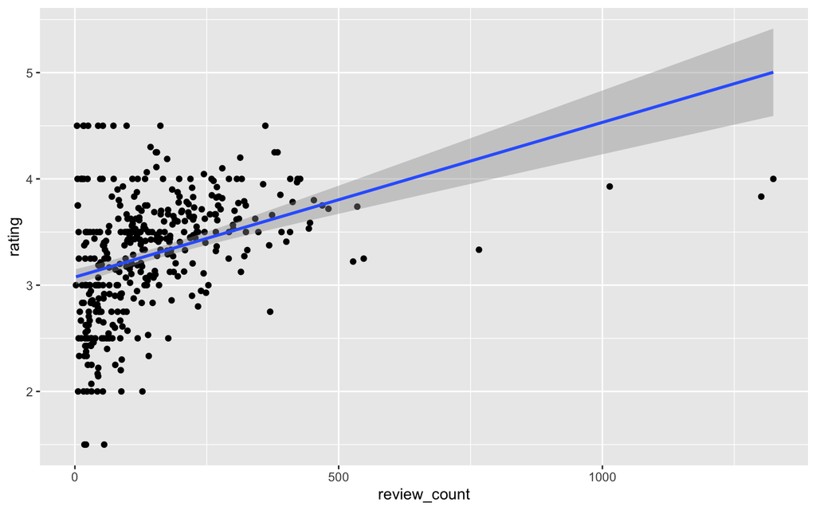

```r
# You don't need to repeat `mapping = aes(x=review_count, y=rating)` twice
ggplot(data = census_restaurants, mapping = aes(x=review_count, y=rating)) + #👈
  geom_point() +
  geom_????(method = ????)
```

If you want to add a specific mapping to a layer, you provide additional mapping to individual layers.

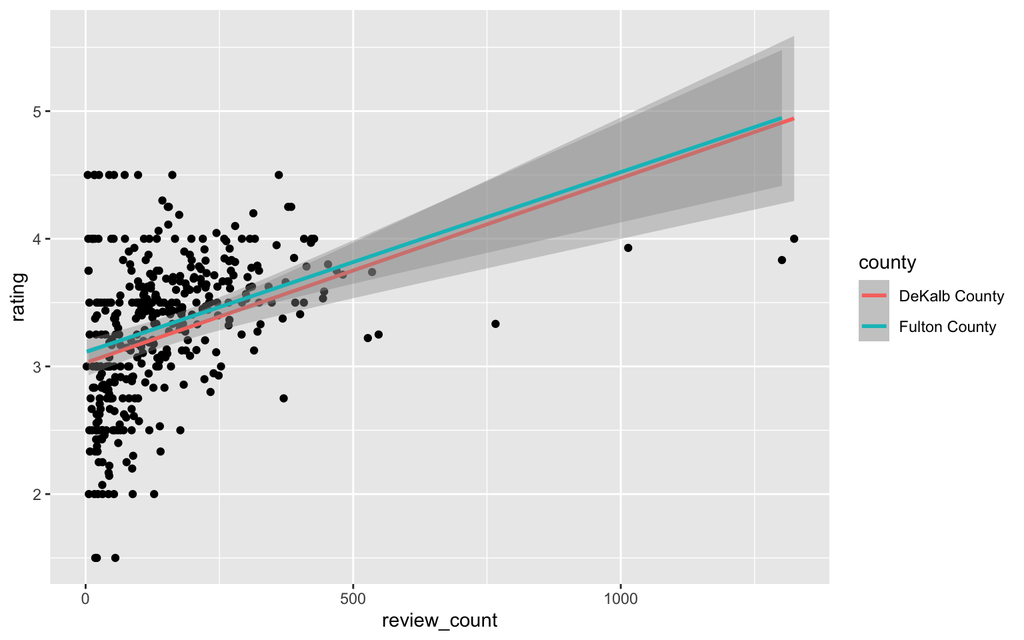

```r
ggplot(data = census_restaurants, mapping = aes(x=review_count, y=rating)) +
  geom_point() +
  geom_????(mapping = aes(color = ????), #👈
            method = ????)
```

You can append `labs()` to specify labels.

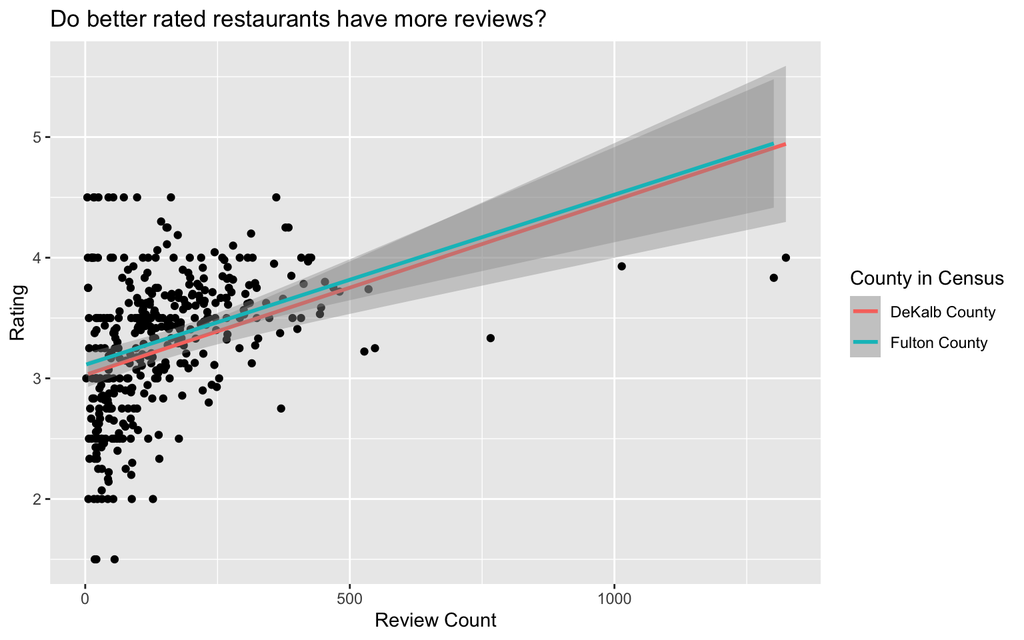

```r
ggplot(data = census_restaurants,
       ???? = aes(x=review_count, y=rating)) +
  geom_point() +
  geom_????(???? = aes(color = ????), method = ????) +
  labs(x = "Review Count", #👈
       y = "Rating",
       color = "County in Census",
       title = "Do better rated restaurants have more reviews?")
```

# Aesthetic options

## Theme

We can change how the plot looks using `theme_<...>`.

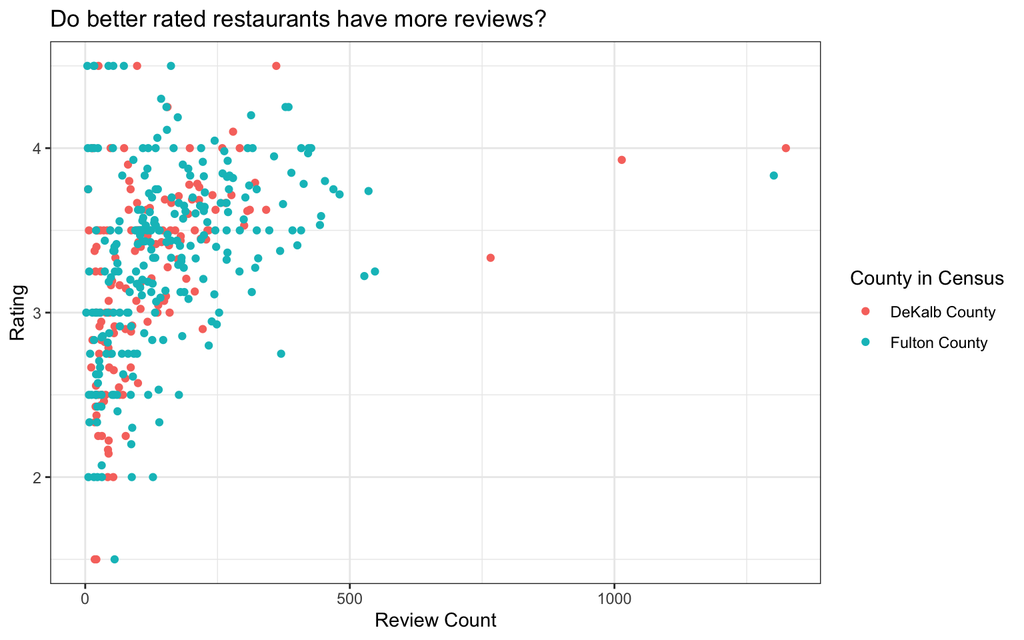

```r
ggplot(data = census_restaurants) +
  geom_point(mapping = aes(x=review_count, y=rating, color = county)) +
  labs(x = "Review Count",
       y = "Rating",
       color = "County in Census",
       title = "Do better rated restaurants have more reviews?") +
  theme_bw()
```

Using a dark theme can make it easier on the eyes.

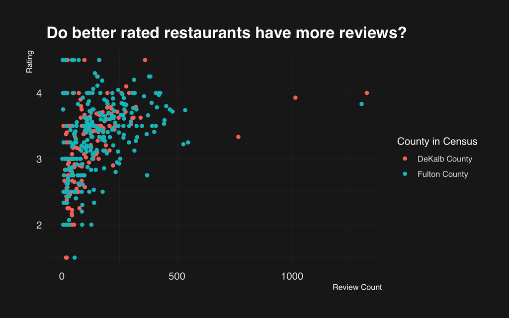

```r
ggplot(data = census_restaurants) +
  geom_point(mapping = aes(x=review_count, y=rating, color = county)) +
  labs(x = "Review Count",
       y = "Rating",
       color = "County in Census",
       title = "Do better rated restaurants have more reviews?") +
  hrbrthemes::theme_modern_rc(
    base_family = "sans", subtitle_family = "sans", caption_family = "sans"
  )
```

## Custom color scheme

If you want to use your custom color choices - for a discrete variable.

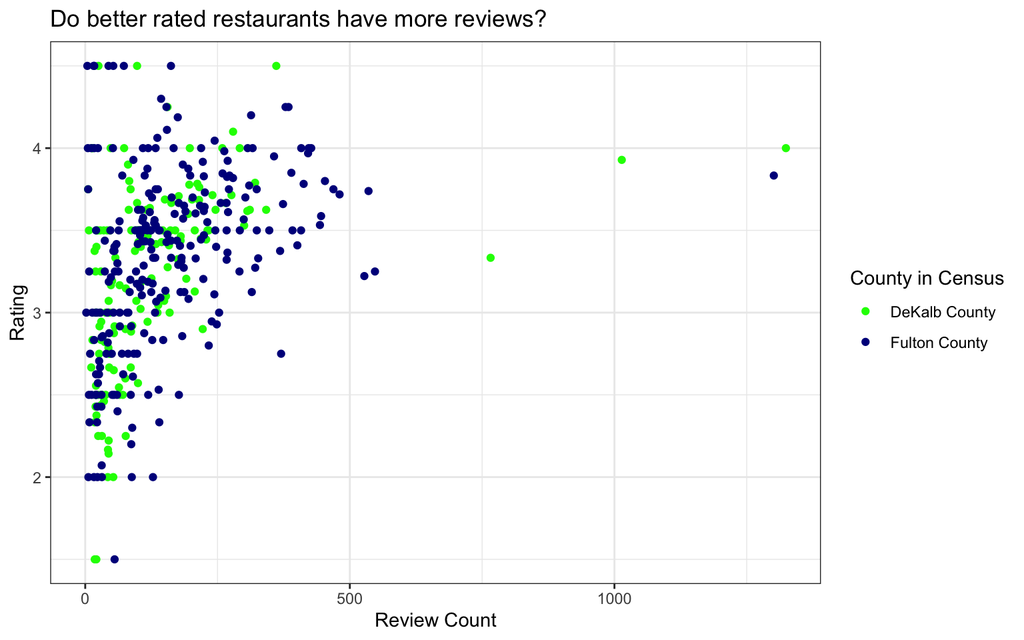

```r
ggplot(data = census_restaurants) +
  geom_point(mapping = aes(x=review_count, y=rating, color = county)) +
  labs(x = "Review Count",
       y = "Rating",
       color = "County in Census",
       title = "Do better rated restaurants have more reviews?") +
  scale_color_manual(values = c("green", "darkblue")) + #👈
  theme_bw()
```

If you want to use your custom color choices - for a continuous variable.

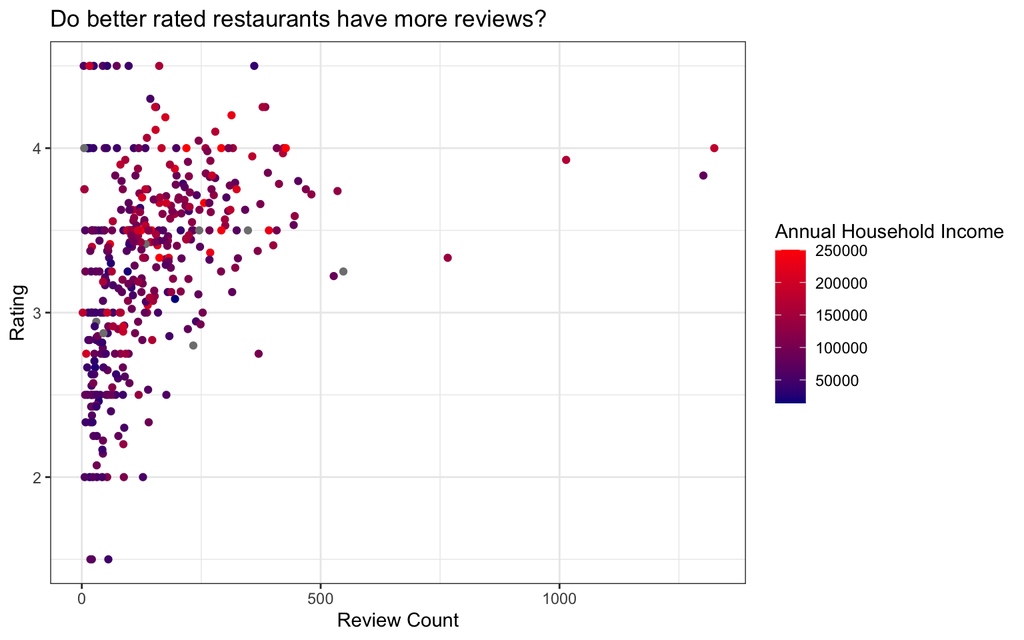

```r
ggplot(data = census_restaurants) +
  geom_point(mapping = aes(x=review_count, y=rating, color = hhincome)) +
  labs(x = "Review Count",
       y = "Rating",
       color = "Annual Household Income",
       title = "Do better rated restaurants have more reviews?") +
  scale_color_gradient(low="darkblue", high="red") + #👈
  theme_bw()
```

### A safer default: viridis

Both examples above work, and you should know how to set colors by hand. But hand-picked palettes are where accessibility quietly breaks. Red-green is by far the most common form of color blindness, and a blue-to-red ramp loses its middle entirely once a figure is printed or viewed in grayscale.

The `viridis` palettes avoid both problems: they stay distinguishable under the common forms of color blindness, and they survive grayscale conversion because brightness increases steadily along the scale. They ship with `ggplot2`, so there is nothing extra to install.

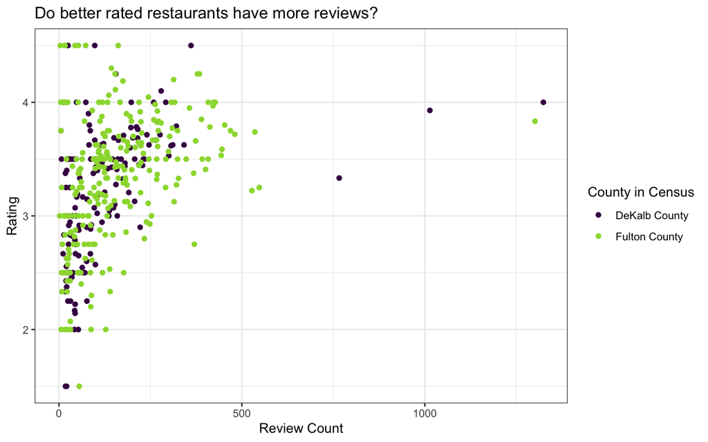

```r
# Discrete variable -> scale_*_viridis_d()
ggplot(data = census_restaurants) +
  geom_point(mapping = aes(x=review_count, y=rating, color = county)) +
  labs(x = "Review Count",
       y = "Rating",
       color = "County in Census",
       title = "Do better rated restaurants have more reviews?") +
  scale_color_viridis_d(end = 0.85) + #👈
  theme_bw()
```

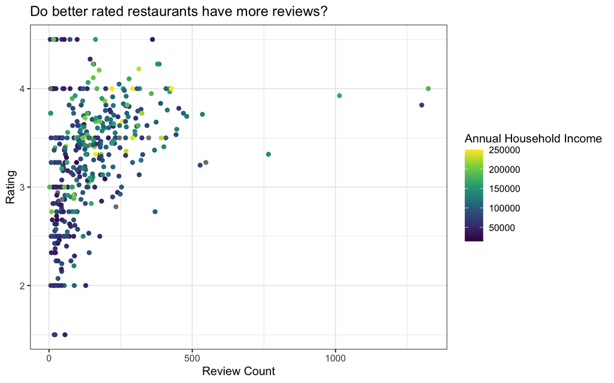

```r
# Continuous variable -> scale_*_viridis_c()
ggplot(data = census_restaurants) +
  geom_point(mapping = aes(x=review_count, y=rating, color = hhincome)) +
  labs(x = "Review Count",
       y = "Rating",
       color = "Annual Household Income",
       title = "Do better rated restaurants have more reviews?") +
  scale_color_viridis_c() + #👈
  theme_bw()
```

> A quick test for any figure you make: convert it to grayscale. If the categories stop being distinguishable, you have encoded meaning in hue alone.

## Data labeling

Let’s label some of the outliers using `ggrepel`.

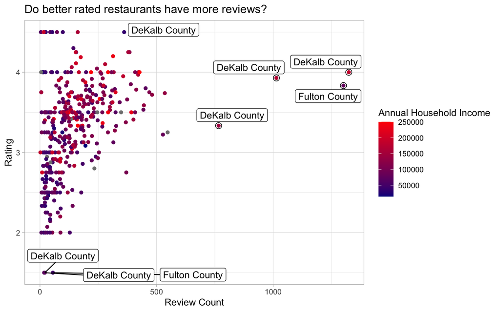

```r
outliers <- census_restaurants %>%
  arrange(desc(review_count)) %>%
  slice(1:4)

ggplot(data = census_restaurants,
       aes(x=review_count, y=rating)) + # moved aes() to here
  geom_point(mapping = aes(color = ????)) + # Colored ones
  geom_point(data = outliers, size = 3, shape = 1, color = "black") + # Black circles
  ggrepel::geom_label_repel(data = census_restaurants, mapping = aes(label = ????)) +
  labs(x = "Review Count",
       y = "Rating",
       color = "Annual Household Income",
       title = "Do better rated restaurants have more reviews?") +
  scale_color_gradient(low="darkblue", high="red") + #👈
  theme_light()
```

## Interactive visualization

How can we convert these plots into interactive ones? The simplest way is to use `ggplotly()` in `plotly` package.

```r
p <- ggplot(data = census_restaurants) +
  geom_point(mapping = aes(x=review_count, y=rating, color = hhincome)) +
  labs(x = "Review Count",
       y = "Rating",
       color = "Annual Household Income",
       title = "Do better rated restaurants have more reviews?") +
  scale_color_gradient(low="darkblue", high="red") + #👈
  theme_bw()

plotly::????(p)
```

[interactive chart not shown]

## 3D scatter plot

Using `plot_ly` in `plotly` package, we can also create a 3-dimensional scatter plot. It is particularly useful when you want to examine associations between four variables.

```r
plotly::????(census_restaurants %>% st_drop_geometry(),
                x = ~hhincome,
                y = ~n,
                z = ~rating,
                color = ~price,
                type = "scatter3d",
                mode = "markers",
                text = ~paste0("Avg. price: ", round(price, 2)),
                hoverinfo = "text")
```

[interactive chart not shown]

# Bar plot

Bar plot is also very commonly used. Note that `ggplot2` automatically creates the y-axis by counting the number of rows for each category of `x`. You can try `restaurants %>% group_by(price) %>% tally()` to check the exact Y-values for this plot.

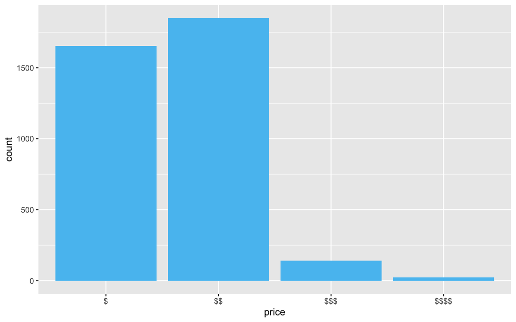

```r
ggplot(data = restaurants) +
  geom_bar(color = NA, mapping = aes(x=price))
```

```r
restaurants %>%
  st_set_geometry(NULL) %>%
  group_by(price) %>%
  tally()
```

```
## # A tibble: 4 × 2
##   price     n
##   <chr> <int>
## 1 $      1653
## 2 $$     1850
## 3 $$$     141
## 4 $$$$     23
```

We can also further break each price level by another categorical variable. We use rating to see the relative frequency of each rating for each price level. This is done by adding `fill=rating` in the mapping.

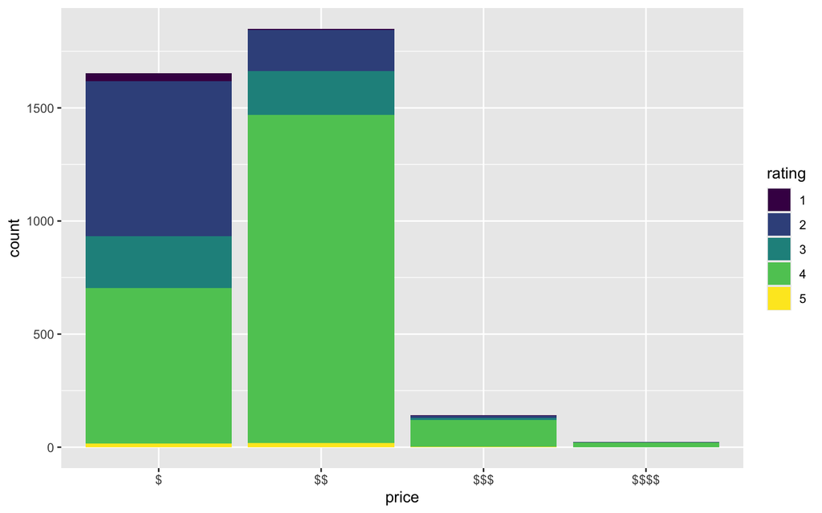

```r
ggplot(data = restaurants %>%
         st_set_geometry(NULL) %>%
         mutate(rating = round(rating,0) %>% #👈
                  factor(ordered = TRUE))) + #👈
         # delete %>% factor(ordered = T) and see what happens
  geom_bar(color = NA, mapping = ???(x=????, fill=rating), position = "stack")
```

By changing `position="stack"` to `position="fill"`, we convert the Y-axis to the proportion within each level of price and fill it up to the top. This shows more clearly how different rating levels are distributed within each price level.

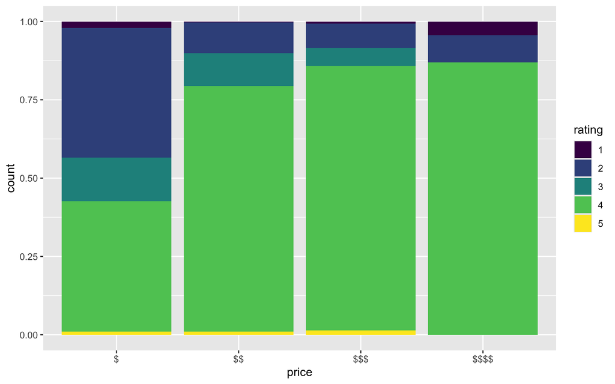

```r
ggplot(data = restaurants %>%
         st_set_geometry(NULL) %>%
         mutate(rating = round(rating,0) %>%
                  factor(ordered = TRUE))) +
  geom_bar(color = NA, mapping = ????(x=????, fill=rating), position = ????) #👈
```

We want rating=5 to be on the top because it is more intuitive to see higher value on top. We can flip the bar plot vertically by adjusting the `levels` when we declare `rating` variable into a factor.

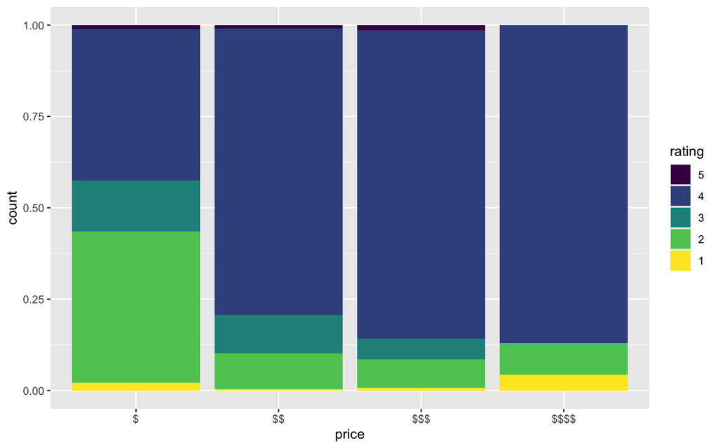

```r
ggplot(data = restaurants %>%
         st_set_geometry(NULL) %>%
         mutate(rating = round(rating,0) %>%
                  factor(levels = c(5,4,3,2,1), #👈
                         ordered = TRUE))) +
  geom_bar(color = NA, mapping = ????(x=????, fill=rating), position = ????)
```

Sometimes, we want to see the exact numbers on top of a bar plot. Let’s add the percentage for each price level as labels.

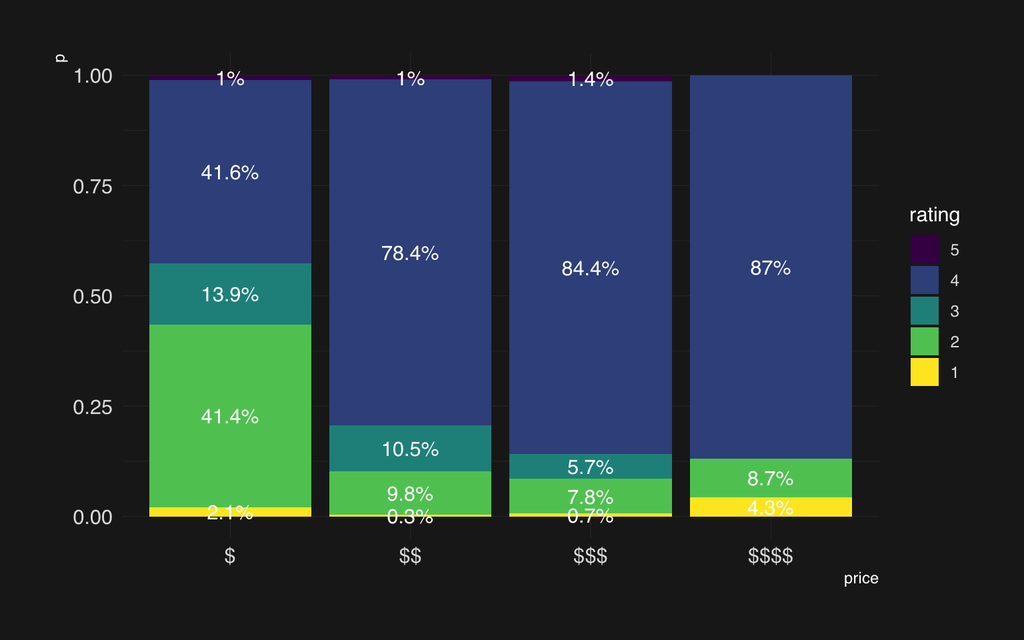

```r
ggplot(data = restaurants %>%
         st_set_geometry(NULL) %>%
         mutate(rating = round(rating,0) %>% factor(levels = c(5,4,3,2,1), ordered = TRUE))) +
  geom_bar(color = NA, ???? = aes(x=????, fill=rating), position = ????) +
  geom_text(data = . %>%
              # Grouping to calculate % by price and by rating
              group_by(price, rating) %>% #👈
              # Count rows
              tally() %>%                 #👈
              # Convert to p
              mutate(p = n / sum(n)) %>%  #👈
              # Re-order to match the order in bar plot
              arrange(desc(rating)),      #👈
            aes(x = price, y = p, label = str_c(round(p,3)*100,"%")), color = "white",
            position = position_stack(vjust=0.5)) +
  hrbrthemes::theme_modern_rc(
    base_family = "sans", subtitle_family = "sans", caption_family = "sans"
  ) # Dark theme because texts are not visible against white bg
```

You can rotate it.

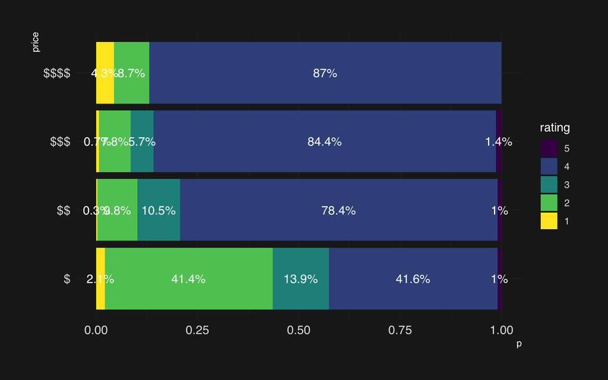

```r
ggplot(data = restaurants %>%
         st_set_geometry(NULL) %>%
         mutate(rating = round(rating,0) %>% factor(levels = c(5,4,3,2,1), ordered = TRUE))) +
  geom_bar(color = NA, ???? = aes(x=????, fill=rating), position = ????) +
  geom_text(data = . %>%
              # Grouping to calculate % by price and by rating
              group_by(price, rating) %>%
              # Count rows
              tally() %>%
              # Convert to p
              mutate(p = n / sum(n)) %>%
              # Re-order to match the order in bar plot
              arrange(desc(rating)),
            aes(x = price, y = p, label = str_c(round(p,3)*100,"%")), color = "white",
            position = position_stack(vjust=0.5)) +
  coord_flip() + #👈
  hrbrthemes::theme_modern_rc(
    base_family = "sans", subtitle_family = "sans", caption_family = "sans"
  ) # Dark theme because texts are not visible against white bg
```

## Customization example (Optional)

I saw this beautiful [example on labeling bar graphs](https://www.cedricscherer.com/2021/07/05/a-quick-how-to-on-labelling-bar-graphs-in-ggplot2/) by CÉDRIC SCHERER and applied it to our data.

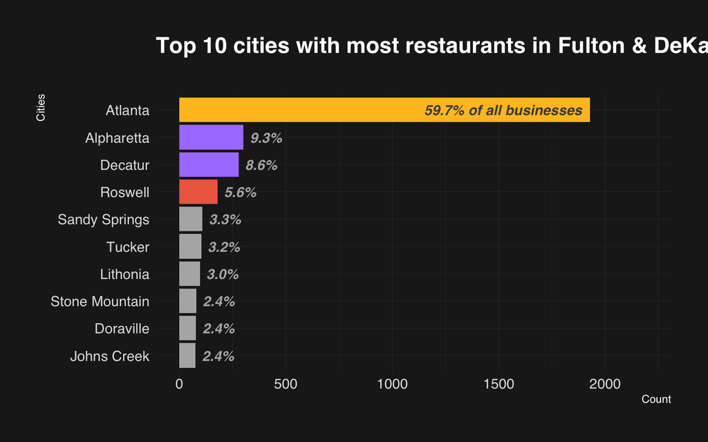

```r
# Code & ideas borrowed heavily from CÉDRIC SCHERER's personal website:
# https://www.cedricscherer.com/2021/07/05/a-quick-how-to-on-labelling-bar-graphs-in-ggplot2/

max_city_n <- 10

rest_by_city <- restaurants %>%
  st_set_geometry(NULL) %>%
  group_by(location.city) %>%
  tally() %>%
  arrange(desc(n)) %>%
  slice(1:max_city_n) %>%
  mutate(location.city = factor(location.city, levels = .$location.city[seq(max_city_n,1)])) %>%
  # Format text label
  mutate(pct = scales::percent(n / sum(n),accuracy = 0.1),
         pct = case_when(row_number() == 1 ~ str_c(pct, " of all businesses"), TRUE ~ pct)) %>%
  # Define aesthetic properties - label location
  mutate(nudge = case_when(row_number()==1 ~ 1.05, TRUE ~ -0.2)) %>%
  # Define aesthetic properties - color
  mutate(color = case_when(row_number()==1 ~ "gray30", TRUE ~ "gray70")) %>%
  # Color palette
  mutate(pal = c(rep('gray70', max_city_n-4), "coral2", "mediumpurple1", "mediumpurple1", "goldenrod1")) %>%
  # with() is required to be able to call variables with referencing to data frame
  with(
    # ggplot
    ggplot(data = .) +
      # Bars
      geom_col(color = NA, mapping = aes(y = location.city, x = n, fill = location.city)) +
      # Text
      geom_text(mapping = aes(y = location.city, x = n, label = pct),
                # Calling aesthetic properties defined above
                hjust=nudge, color=color,
                # Font styling
                fontface="bold.italic") +
      # Stretch x axis
      scale_x_continuous(limits = c(NA, 2200)) +
      # Custom palette
      scale_fill_manual(values = pal, guide="none") +
      # Labels
      labs(x = "Count", y = "Cities", title = "Top 10 cities with most restaurants in Fulton & DeKalb Counties\n") +
      # Dark theme
      hrbrthemes::theme_modern_rc(
    base_family = "sans", subtitle_family = "sans", caption_family = "sans"
  )
  )

rest_by_city
```

# Histogram, box plot, & violin plot

## Histogram

A histogram displays the distribution of a variable. It first assigns observations (i.e., rows) of the given variable (i.e., a column) into bins (e.g., 0–99, 100–199, 200–299, etc.) and counts the number of observations in each bin. The taller a bar, the more observations fall into that bin.

Let’s examine the distribution of review counts using a histogram.

> Observe what changes in each plot.

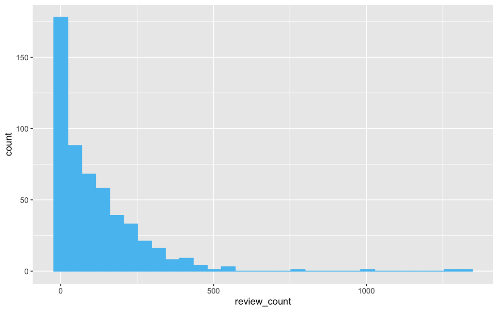

```r
ggplot(census_restaurants) +
  geom_histogram(mapping = ????(x = ????))
```

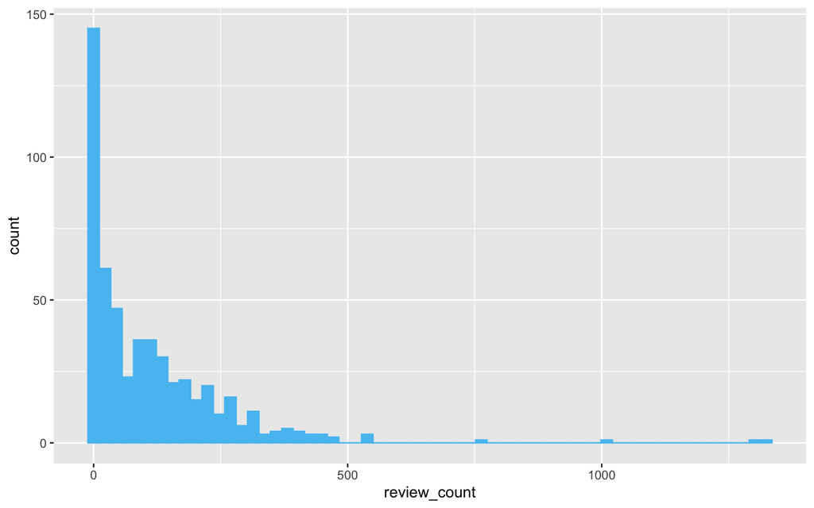

```r
ggplot(census_restaurants) +
  geom_histogram(mapping = ????(x = ????),
                 bins = 60) #👈 increase the number of bins from 30 to 60. You get more bars.
```

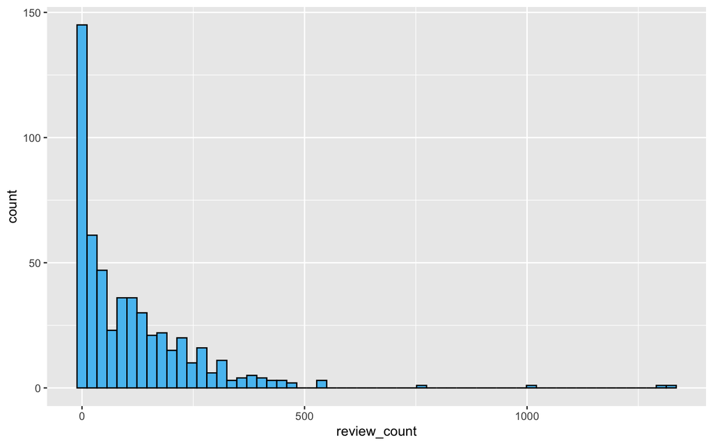

```r
ggplot(census_restaurants) +
  geom_histogram(mapping = ????(x = ????),
                 bins = 60,
                 color="black")  #👈 color of the outline
```